# HW2

Adrián Arribas and Rodrigo Milton Campos

2025-12-19

# Homework 2

We choose “Exited” as the target variable for our study to determine whether a customer leaves the bank or not.

Here are the rest of the variables:

CustomerId: A unique numerical identification number for each customer.

CreditScore: A numerical value used to measure the customer’s creditworthiness.

Gender: The gender of the customer (Male or Female).

Balance: The amount of money currently held in the customer’s bank account.

NumOfProducts: The total number of different bank products or services used by the customer.

HasCrCard: A binary indicator showing whether the customer possesses a credit card.

IsActiveMember: A binary indicator representing whether the customer is considered an active member of the bank.

Age: The age of the customer.

Geography: The region where the customer is located (Texas, California, or Alabama).

EstimatedSalary: The projected annual salary of the customer.

Surname: The customer’s last name.

Tenure: The number of years the customer has been a client of the bank.

We load all the necessary libraries:

Loading the dataset

```r
set.seed(123)
pre_data = read.csv("Data.csv")
```

## Preprocessing and Visualization

```r
summary(pre_data)
```

```
##        X          RowNumber       CustomerId        CreditScore
##  Min.   :   0   Min.   :    1   Min.   :15565701   Min.   :350.0
##  1st Qu.:2500   1st Qu.: 2501   1st Qu.:15628528   1st Qu.:584.0
##  Median :5000   Median : 5000   Median :15690738   Median :652.0
##  Mean   :5000   Mean   : 5000   Mean   :15690941   Mean   :650.5
##  3rd Qu.:7499   3rd Qu.: 7500   3rd Qu.:15753234   3rd Qu.:718.0
##  Max.   :9999   Max.   :10000   Max.   :15815690   Max.   :850.0
##
##     Gender             Balance       NumOfProducts    HasCrCard
##  Length:10000       Min.   :     0   Min.   :1.00   Min.   :0.0000
##  Class :character   1st Qu.:     0   1st Qu.:1.00   1st Qu.:0.0000
##  Mode  :character   Median : 97199   Median :1.00   Median :1.0000
##                     Mean   : 76486   Mean   :1.53   Mean   :0.7055
##                     3rd Qu.:127644   3rd Qu.:2.00   3rd Qu.:1.0000
##                     Max.   :250898   Max.   :4.00   Max.   :1.0000
##
##  IsActiveMember        Age         Geography         EstimatedSalary
##  Min.   :0.0000   Min.   :18.00   Length:10000       Min.   :    11.58
##  1st Qu.:0.0000   1st Qu.:32.00   Class :character   1st Qu.: 51136.84
##  Median :1.0000   Median :37.00   Mode  :character   Median :100608.44
##  Mean   :0.5151   Mean   :38.87                      Mean   :100294.79
##  3rd Qu.:1.0000   3rd Qu.:44.00                      3rd Qu.:149584.73
##  Max.   :1.0000   Max.   :92.00                      Max.   :199992.48
##                   NA's   :640                        NA's   :792
##    Surname              Exited           Tenure
##  Length:10000       Min.   :0.0000   Min.   :  0.000
##  Class :character   1st Qu.:0.0000   1st Qu.:  3.000
##  Mode  :character   Median :0.0000   Median :  5.000
##                     Mean   :0.1703   Mean   :  7.218
##                     3rd Qu.:0.0000   3rd Qu.:  7.000
##                     Max.   :1.0000   Max.   :100.000
##
```

Remove ID’s

```r
pre_data = pre_data[,4:15]
```

We also remove the surnames, as we will not be using them

```r
pre_data = pre_data[,-10]
```

Creating dummy variables for each state

```r
pre_data$Geography = as.factor(pre_data$Geography)
str(pre_data$Geography)
```

```
##  Factor w/ 3 levels "Alabama","California",..: 3 2 3 3 2 2 3 1 3 3 ...
```

```r
levels(pre_data$Geography)
```

```
## [1] "Alabama"    "California" "Texas"
```

```r
pre_data$Texas = ifelse(pre_data$Geography == "Texas", 1, 0)
pre_data$California = ifelse(pre_data$Geography == "California", 1, 0)
pre_data$Alabama = ifelse(pre_data$Geography == "Alabama", 1, 0)

head(pre_data[c("Geography", "Alabama", "California", "Texas")])
```

```
##    Geography Alabama California Texas
## 1      Texas       0          0     1
## 2 California       0          1     0
## 3      Texas       0          0     1
## 4      Texas       0          0     1
## 5 California       0          1     0
## 6 California       0          1     0
```

```r
# Removing geography
pre_data = subset(pre_data, select = -c(Geography))
```

Checking NA’s

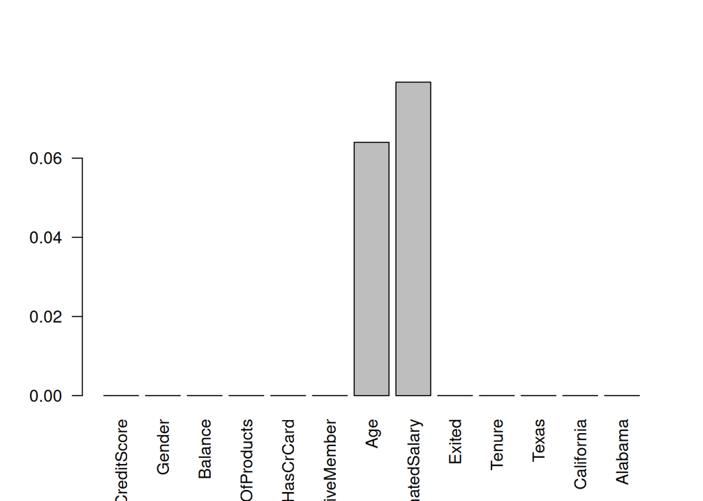

```r
barplot(colMeans(is.na(pre_data)), las=2)
```

Cleaning NA’s

```r
clean = mice(pre_data, method = "rf", m = 5)
data = complete(clean)
```

It is safe to assume a tenure of 100 years is not the intended value and probably a typo or a mistake

```r
data = data[data$Tenure < 100,]
```

Checking for correlation between variables

```r
data$Gender = as.factor(data$Gender)
levels(data$Gender)
```

```
## [1] "Female" "Male"
```

```r
data_num = data[,-2]
data_num$Gender = as.numeric(data$Gender) - 1 # 0 for female and 1 for male
```

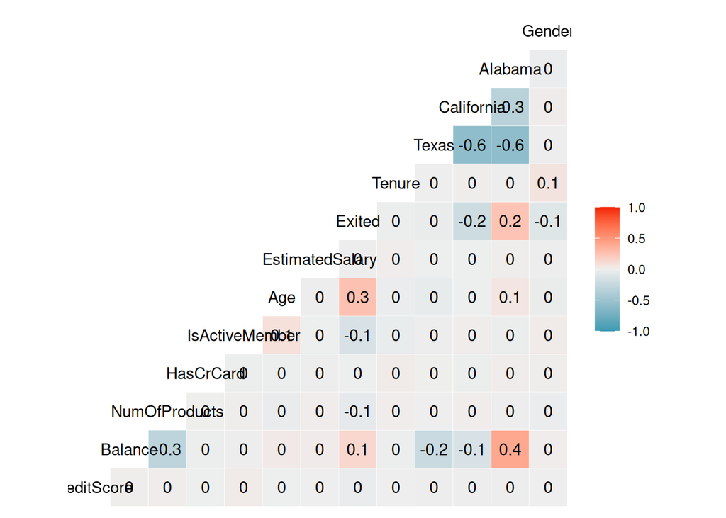

Factor Conversion

```r
#Convert Gender to Factor
data$Gender = as.factor(data$Gender)

#Convert Exited to Factor
data$Exited = as.factor(data$Exited)

#Convert Numerical Categorical Variables to Factors
data$NumOfProducts = as.factor(data$NumOfProducts)
data$HasCrCard = as.factor(data$HasCrCard)
data$IsActiveMember = as.factor(data$IsActiveMember)
data$Tenure = as.factor(data$Tenure)

#Check the final structure
str(data)
```

```
## 'data.frame':    9755 obs. of  13 variables:
##  $ CreditScore    : int  619 608 502 699 850 645 822 376 501 684 ...
##  $ Gender         : Factor w/ 2 levels "Female","Male": 1 1 1 1 1 2 2 1 2 2 ...
##  $ Balance        : num  0 83808 159661 0 125511 ...
##  $ NumOfProducts  : Factor w/ 4 levels "1","2","3","4": 1 1 3 2 1 2 2 4 2 1 ...
##  $ HasCrCard      : Factor w/ 2 levels "0","1": 2 1 2 1 2 2 2 2 1 2 ...
##  $ IsActiveMember : Factor w/ 2 levels "0","1": 2 2 1 1 2 1 2 1 2 2 ...
##  $ Age            : int  42 41 42 39 43 44 50 29 66 51 ...
##  $ EstimatedSalary: num  101349 112543 113932 93827 79084 ...
##  $ Exited         : Factor w/ 2 levels "0","1": 2 1 2 1 1 1 1 2 1 1 ...
##  $ Tenure         : Factor w/ 11 levels "0","1","2","3",..: 3 2 9 2 3 9 8 5 5 3 ...
##  $ Texas          : num  1 0 1 1 0 0 1 0 1 1 ...
##  $ California     : num  0 1 0 0 1 1 0 0 0 0 ...
##  $ Alabama        : num  0 0 0 0 0 0 0 1 0 0 ...
```

We visualize the target variable

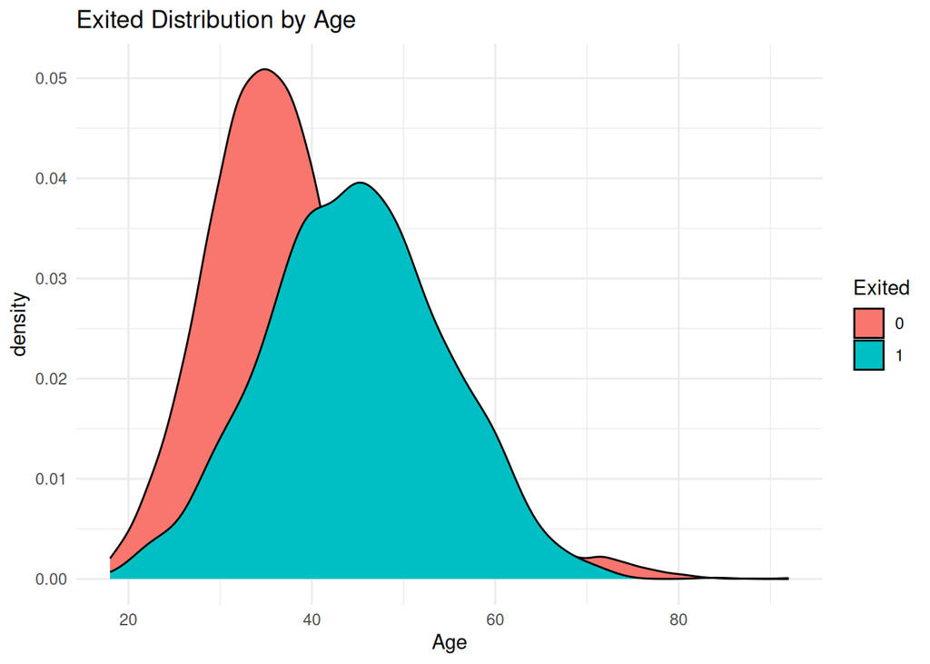

```r
ggplot(data, aes(x = Age, fill = Exited)) +
  geom_density() +
  labs(title = "Exited Distribution by Age",
       x = "Age",
       fill = "Exited") +
  theme_minimal()
```

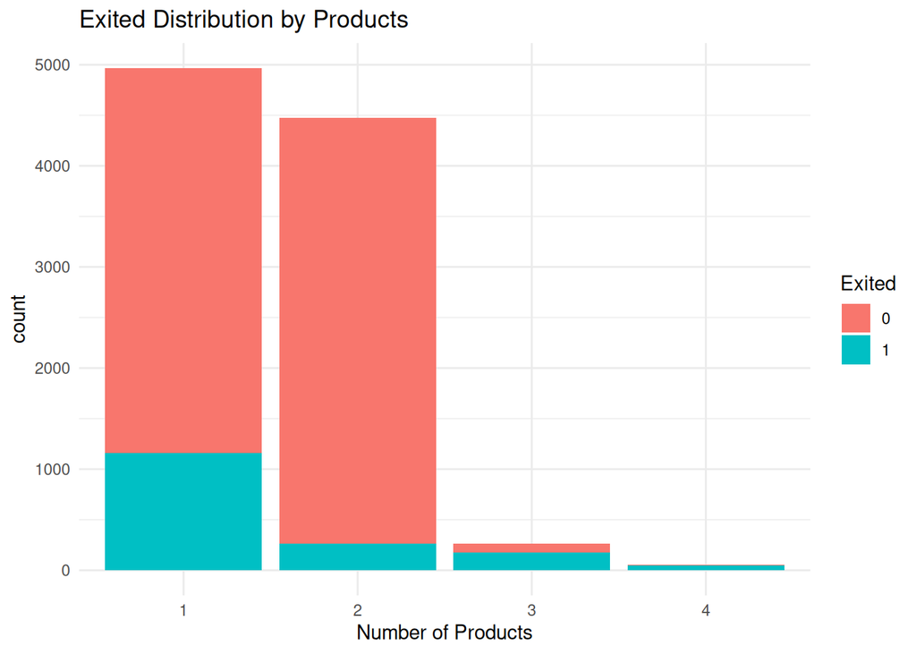

```r
ggplot(data, aes(x = NumOfProducts, fill = Exited)) +
  geom_bar() +
  labs(title = "Exited Distribution by Products",
       x = "Number of Products",
       fill = "Exited") +
  theme_minimal()
```

Even though the count is rather small, there is a much bigger proportion of customers that exited when looking at those with a higher number of products used.

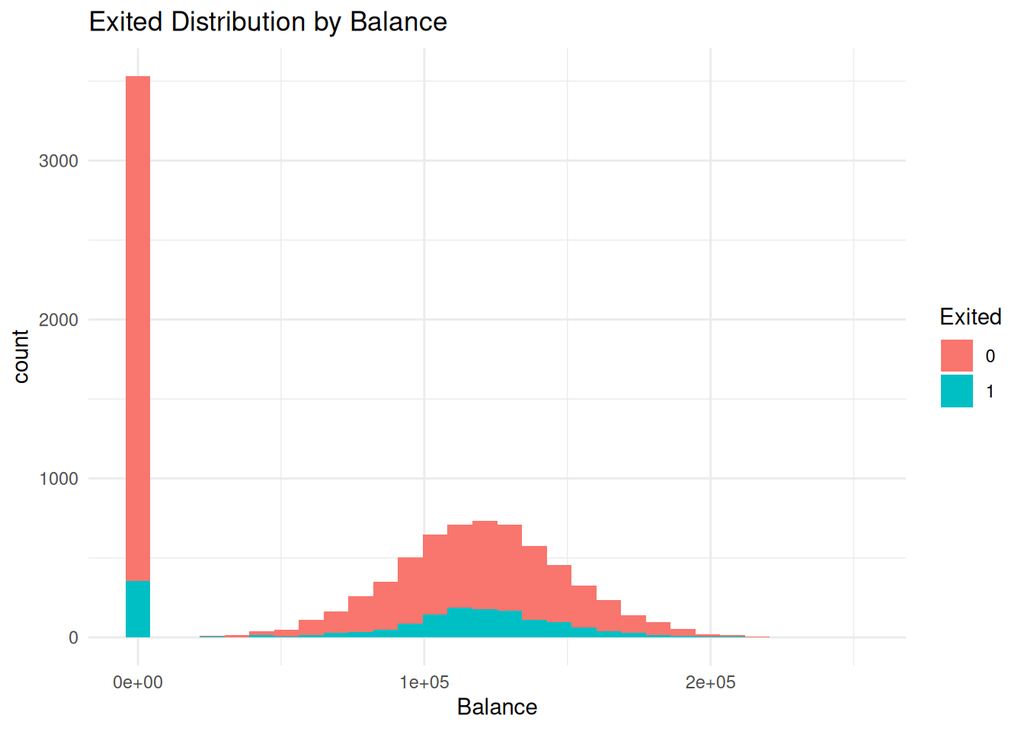

```r
ggplot(data, aes(x = Balance, fill = Exited)) +
  geom_histogram() +
  labs(title = "Exited Distribution by Balance",
       x = "Balance",
       fill = "Exited") +
  theme_minimal()
```

Yields no clear conclusion as to how the balance affects the target variable.

## Classification

Data partition and display check

```r
train_index = createDataPartition(data$Exited, p = 0.7, list = FALSE)

# Split the data
train_data = data[train_index, ]
test_data  = data[-train_index, ]

# Display
prop.table(table(train_data$Exited))
```

```
##
##         0         1
## 0.8316252 0.1683748
```

```r
prop.table(table(test_data$Exited))
```

```
##
##         0         1
## 0.8317949 0.1682051
```

### Random Forest

Training the random forest

```r
rf_model = randomForest(
  Exited ~ .,
  data = train_data,
  ntree = 500,
  importance = TRUE
)

# Print the model summary
print(rf_model)
```

```
##
## Call:
##  randomForest(formula = Exited ~ ., data = train_data, ntree = 500,      importance = TRUE)
##                Type of random forest: classification
##                      Number of trees: 500
## No. of variables tried at each split: 3
##
##         OOB estimate of  error rate: 11.23%
## Confusion matrix:
##      0   1 class.error
## 0 5527 153  0.02693662
## 1  614 536  0.53391304
```

Evaluating the random forest

```r
rf_predictions <- predict(rf_model, newdata = test_data)

conf_matrix_rf <- confusionMatrix(rf_predictions,
                                  test_data$Exited,
                                  positive = "1")

conf_matrix_rf
```

```
## Confusion Matrix and Statistics
##
##           Reference
## Prediction    0    1
##          0 2370  280
##          1   63  212
##
##                Accuracy : 0.8827
##                  95% CI : (0.8705, 0.8942)
##     No Information Rate : 0.8318
##     P-Value [Acc > NIR] : 8.046e-15
##
##                   Kappa : 0.4915
##
##  Mcnemar's Test P-Value : < 2.2e-16
##
##             Sensitivity : 0.43089
##             Specificity : 0.97411
##          Pos Pred Value : 0.77091
##          Neg Pred Value : 0.89434
##              Prevalence : 0.16821
##          Detection Rate : 0.07248
##    Detection Prevalence : 0.09402
##       Balanced Accuracy : 0.70250
##
##        'Positive' Class : 1
##
```

#### ROC for Random Forest

We use the ROC curve to obtain the optimal threshold.

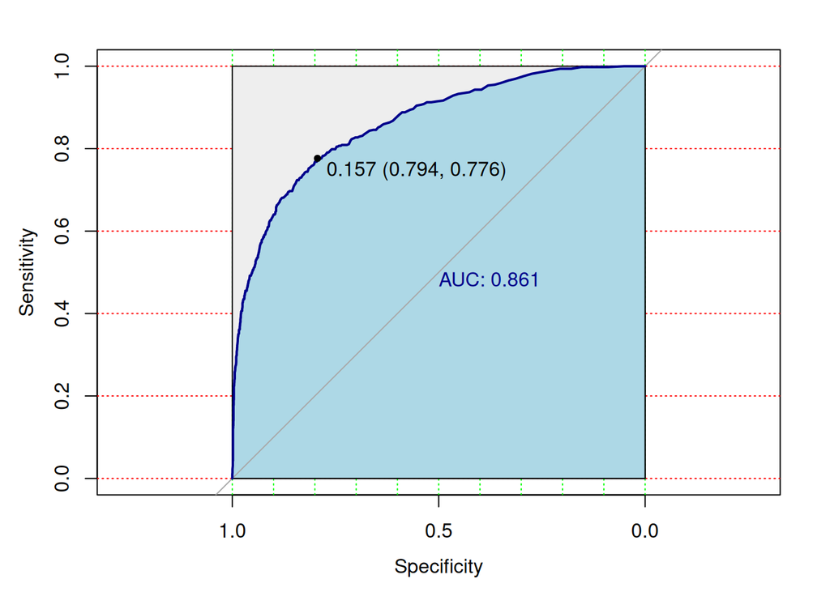

```r
rf_prob <- predict(rf_model, newdata = test_data, type = "prob")
plot.roc(test_data$Exited, rf_prob[,2], col="darkblue", print.auc = TRUE,  auc.polygon=TRUE, grid=c(0.1, 0.2),
         grid.col=c("green", "red"), max.auc.polygon=TRUE,
         auc.polygon.col="lightblue", print.thres=TRUE)
```

We seem to obtain an optimal threshold of about 0.15 It makes sense for us to obtain a low threshold due to the imbalance we can see in the positive and negative values for the target variable.

```r
threshold_1 = 0.15

# New model with "optimal" threshold
rf_model = randomForest(
  Exited ~ .,
  data = train_data,
  ntree = 500,
  importance = TRUE,
  cutoff = c(0.85, 0.15)
)

rf_predictions <- predict(rf_model, newdata = test_data)

conf_matrix_rf <- confusionMatrix(rf_predictions,
                                  test_data$Exited,
                                  positive = "1")

conf_matrix_rf
```

```
## Confusion Matrix and Statistics
##
##           Reference
## Prediction    0    1
##          0 1913  107
##          1  520  385
##
##                Accuracy : 0.7856
##                  95% CI : (0.7703, 0.8004)
##     No Information Rate : 0.8318
##     P-Value [Acc > NIR] : 1
##
##                   Kappa : 0.4261
##
##  Mcnemar's Test P-Value : <2e-16
##
##             Sensitivity : 0.7825
##             Specificity : 0.7863
##          Pos Pred Value : 0.4254
##          Neg Pred Value : 0.9470
##              Prevalence : 0.1682
##          Detection Rate : 0.1316
##    Detection Prevalence : 0.3094
##       Balanced Accuracy : 0.7844
##
##        'Positive' Class : 1
##
```

It seems to have traded a substantial increase in Sensitivity in exchange for a noticeable decrease in Specificity. The Accuracy is also lower.

### Logistic Regression

Emphasis on interpretation

```r
glm_model = glm(Exited ~ .,
                 data = train_data,
                 family = binomial(link = "logit"))

summary(glm_model)
```

```
##
## Call:
## glm(formula = Exited ~ ., family = binomial(link = "logit"),
##     data = train_data)
##
## Coefficients: (1 not defined because of singularities)
##                   Estimate Std. Error z value Pr(>|z|)
## (Intercept)     -1.848e+00  3.771e-01  -4.902 9.49e-07 ***
## CreditScore     -6.148e-04  3.987e-04  -1.542   0.1230
## GenderMale      -4.807e-01  7.946e-02  -6.049 1.45e-09 ***
## Balance         -2.892e-07  7.856e-07  -0.368   0.7128
## NumOfProducts2  -1.619e+00  9.744e-02 -16.613  < 2e-16 ***
## NumOfProducts3   2.227e+00  2.044e-01  10.894  < 2e-16 ***
## NumOfProducts4   3.117e+00  4.941e-01   6.308 2.82e-10 ***
## HasCrCard1      -4.279e-02  8.625e-02  -0.496   0.6198
## IsActiveMember1 -1.091e+00  8.254e-02 -13.213  < 2e-16 ***
## Age              7.125e-02  3.663e-03  19.449  < 2e-16 ***
## EstimatedSalary  3.559e-07  6.776e-07   0.525   0.5994
## Tenure1         -1.398e-01  2.141e-01  -0.653   0.5139
## Tenure2         -3.204e-01  2.197e-01  -1.458   0.1448
## Tenure3         -2.870e-01  2.199e-01  -1.305   0.1917
## Tenure4         -2.209e-02  2.161e-01  -0.102   0.9186
## Tenure5         -2.234e-01  2.174e-01  -1.027   0.3042
## Tenure6         -2.780e-02  2.168e-01  -0.128   0.8980
## Tenure7         -3.653e-01  2.211e-01  -1.652   0.0985 .
## Tenure8         -1.726e-01  2.205e-01  -0.783   0.4337
## Tenure9         -1.431e-01  2.153e-01  -0.665   0.5061
## Tenure10        -2.871e-01  3.305e-01  -0.869   0.3850
## Texas           -1.002e+00  8.942e-02 -11.206  < 2e-16 ***
## California      -3.181e+00  1.743e-01 -18.256  < 2e-16 ***
## Alabama                 NA         NA      NA       NA
## ---
## Signif. codes:  0 '***' 0.001 '**' 0.01 '*' 0.05 '.' 0.1 ' ' 1
##
## (Dispersion parameter for binomial family taken to be 1)
##
##     Null deviance: 6192.1  on 6829  degrees of freedom
## Residual deviance: 4243.0  on 6807  degrees of freedom
## AIC: 4289
##
## Number of Fisher Scoring iterations: 6
```

We can determine what variables are more significant for predicting the exit of customers by looking at the “Estimate” column while bearing in mind the strength of these predictors is given by the p-value assigned to them. Therefore, we check primarily those with “***” (smallest p-value). Positive values mean a higher value for the input variable yield a higher probability of the customer leaving.

Taking this into account, it seems that Age is a factor that increases the risk of churn (positive Estimate value), and so is being from Alabama (or registering there for the bank’s services), as we can see from the negative Estimate values for California and Texas.

Being male (Gender) and being an active member are two factors that decrease the risk of churn, as can be determined by seeing the negative values for Estimate.

```r
# Predicting probabilities on the test data
glm_prob = predict(glm_model, newdata = test_data, type = "response")

# Converting probabilities to class predictions (using default threshold of 0.5)
glm_prediction = factor(ifelse(glm_prob > 0.5, 1, 0), levels = c("0", "1"))

# Creating the Confusion Matrix
conf_matrix_glm = confusionMatrix(glm_prediction,
                                  test_data$Exited,
                                  positive = "1")

# Print results
conf_matrix_glm
```

```
## Confusion Matrix and Statistics
##
##           Reference
## Prediction    0    1
##          0 2345  318
##          1   88  174
##
##                Accuracy : 0.8612
##                  95% CI : (0.8481, 0.8735)
##     No Information Rate : 0.8318
##     P-Value [Acc > NIR] : 7.558e-06
##
##                   Kappa : 0.3903
##
##  Mcnemar's Test P-Value : < 2.2e-16
##
##             Sensitivity : 0.35366
##             Specificity : 0.96383
##          Pos Pred Value : 0.66412
##          Neg Pred Value : 0.88059
##              Prevalence : 0.16821
##          Detection Rate : 0.05949
##    Detection Prevalence : 0.08957
##       Balanced Accuracy : 0.65874
##
##        'Positive' Class : 1
##
```

#### ROC for Logistic Regression

We use the ROC curve to obtain the optimal threshold.

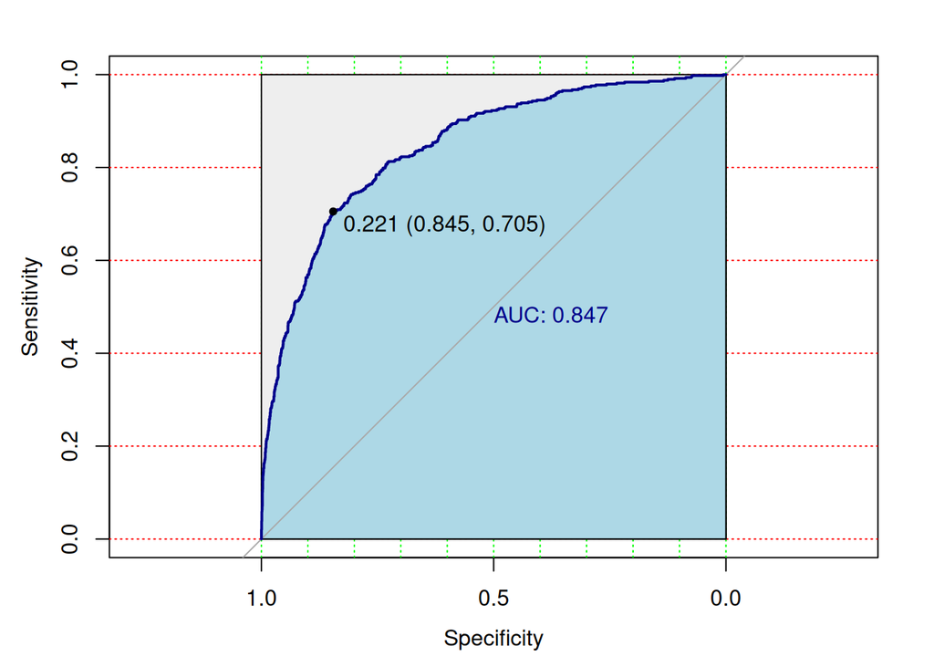

```r
plot.roc(test_data$Exited, glm_prob, col="darkblue", print.auc = TRUE,  auc.polygon=TRUE, grid=c(0.1, 0.2),
         grid.col=c("green", "red"), max.auc.polygon=TRUE,
         auc.polygon.col="lightblue", print.thres=TRUE)
```

We can try a threshold of around 0.2:

```r
threshold_2 = 0.2

# Evaluation of Logistic Regression Model with "optimal" threshold
glm_prediction = factor(ifelse(glm_prob > threshold_2, 1, 0), levels = c("0", "1"))


conf_matrix_glm = confusionMatrix(glm_prediction,
                                  test_data$Exited,
                                  positive = "1")

conf_matrix_glm
```

```
## Confusion Matrix and Statistics
##
##           Reference
## Prediction    0    1
##          0 2001  139
##          1  432  353
##
##                Accuracy : 0.8048
##                  95% CI : (0.7899, 0.819)
##     No Information Rate : 0.8318
##     P-Value [Acc > NIR] : 0.9999
##
##                   Kappa : 0.4363
##
##  Mcnemar's Test P-Value : <2e-16
##
##             Sensitivity : 0.7175
##             Specificity : 0.8224
##          Pos Pred Value : 0.4497
##          Neg Pred Value : 0.9350
##              Prevalence : 0.1682
##          Detection Rate : 0.1207
##    Detection Prevalence : 0.2684
##       Balanced Accuracy : 0.7700
##
##        'Positive' Class : 1
##
```

#### Cost Matrix

We define a possible cost matrix and obtain the optimal threshold for it.

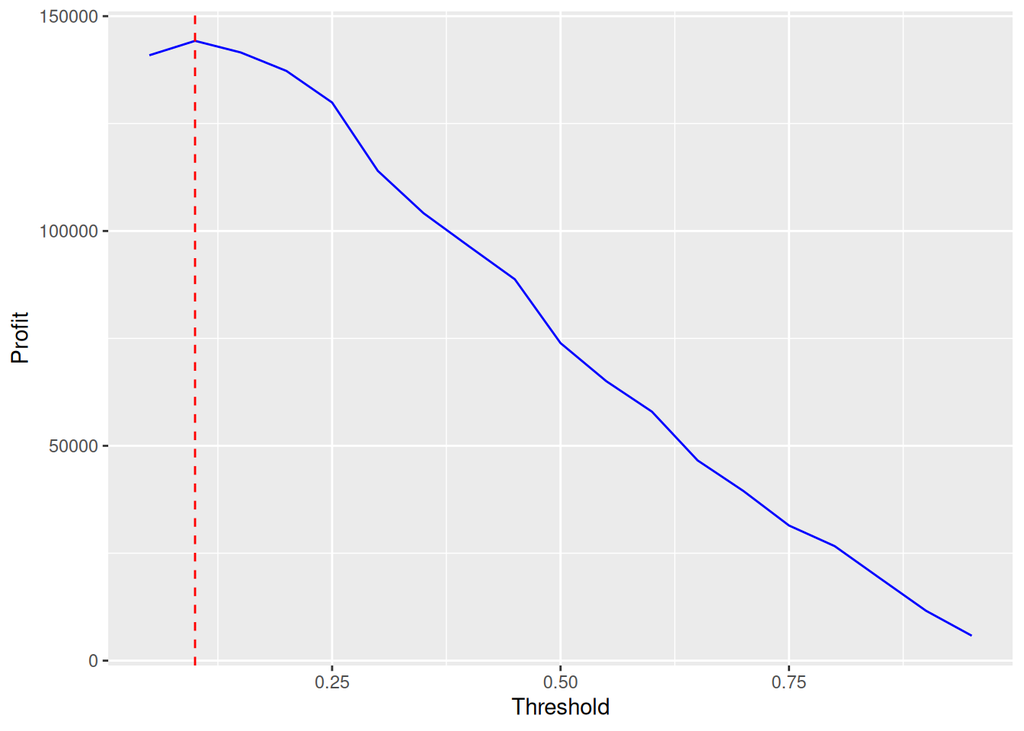

```r
churn_cost = 500          # Lifetime value of a client
retention = 50     # Cost of the incentive

thresholds = seq(0.05, 0.95, 0.05)
total_profits = data.frame(Threshold = thresholds, Profit = rep(0, length(thresholds)))
for (i in 1:length(thresholds)) {
 threshold = thresholds[i]
 preds = ifelse(glm_prob >= threshold, 1, 0)

 tp = sum(preds == 1 & test_data$Exited == 1)
 fp = sum(preds == 1 & test_data$Exited == 0)

 total_profits$Profit[i] = (tp * (churn_cost - retention)) - (fp * retention)
}

ggplot(total_profits, aes(x = Threshold, y = Profit))+
  geom_line(color = "blue")+
  geom_vline(xintercept = thresholds[which.max(total_profits$Profit)], linetype="dashed", color="red")
```

We can observe the best threshold for economic gain we have tested is 0.1, which makes sense given the much higher cost of losing a customer with respect to offering an incentive for retention.

## Feature Selection

```r
importance(rf_model) # Raw scores
```

```
##                          0         1 MeanDecreaseAccuracy MeanDecreaseGini
## CreditScore      1.9348538 -1.624913           0.72789299        189.81393
## Gender           4.2247635  3.513478           5.44783272         29.36318
## Balance          9.6909086 30.890219          29.55207308        207.88828
## NumOfProducts   61.3020399 76.452107          84.37512304        211.25281
## HasCrCard       -1.4673763  1.708795          -0.39576437         25.44905
## IsActiveMember  35.4306178 33.223543          43.51882076         69.55082
## Age             59.4757175 81.698978          87.46943710        357.62132
## EstimatedSalary  0.3885002 -0.556295           0.04040328        187.95158
## Tenure           2.0270030  2.315639           2.99254238        169.75447
## Texas            6.2809345 22.688645          19.57069208         31.73452
## California      28.3362978 30.820796          34.16491927         71.16553
## Alabama          2.7738294 30.731784          28.38629786         75.38872
```

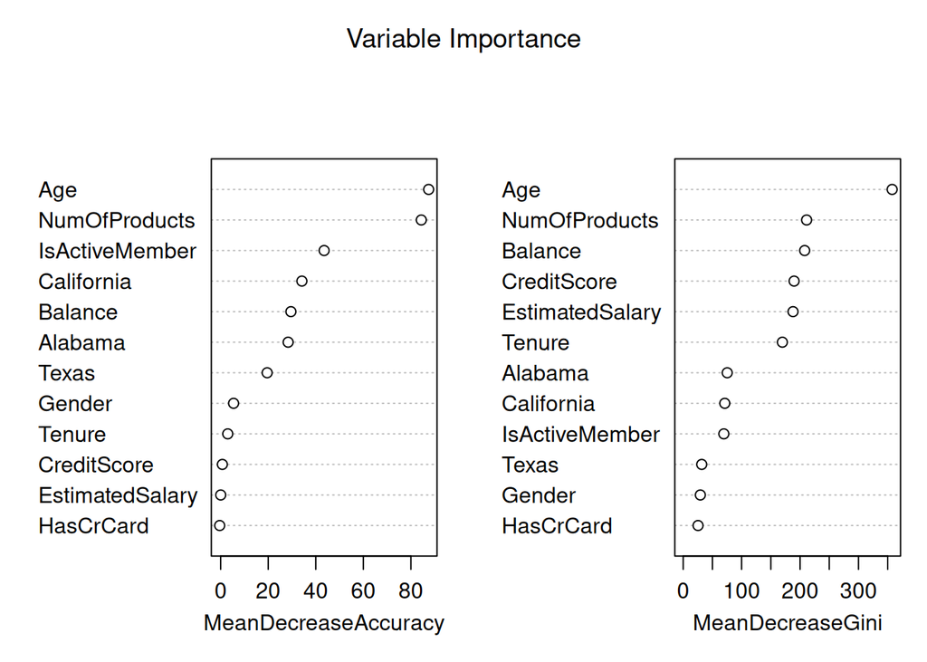

```r
varImpPlot(rf_model, main = "Variable Importance")
```

```r
## Model Comparison: Reduced Feature Set

# Define the reduced formula based on feature importance analysis:
# We will use the thresholds obtained by the ROC curves
reduced_formula = Exited ~ Age + Balance + NumOfProducts + CreditScore + IsActiveMember + California + Alabama + Texas

# Training Reduced Random Forest
rf_reduced = randomForest(
  reduced_formula,
  data = train_data,
  ntree = 500,
  importance = TRUE,
  cutoff = c(1 - threshold_1, threshold_1)
)

# Evaluating Reduced Random Forest
rf_reduced_pred = predict(rf_reduced, newdata = test_data)
conf_matrix_rf_reduced = confusionMatrix(rf_reduced_pred,
                                        test_data$Exited,
                                        positive = "1")


# Training Reduced Logistic Regression
glm_reduced = glm(reduced_formula,
                 data = train_data,
                 family = binomial(link = "logit"))

# Evaluating Reduced Logistic Regression
glm_reduced_prob = predict(glm_reduced, newdata = test_data, type = "response")
glm_reduced_pred = factor(ifelse(glm_reduced_prob > threshold_2, 1, 0), levels = c("0", "1"))
conf_matrix_glm_reduced = confusionMatrix(glm_reduced_pred,
                                        test_data$Exited,
                                        positive = "1")
```

```r
# Function to extract key metrics
extract_metrics = function(conf_matrix, model_name) {
  data.frame(
    Model = model_name,
    Accuracy = conf_matrix$overall['Accuracy'],
    Sensitivity = conf_matrix$byClass['Sensitivity'],
    Specificity = conf_matrix$byClass['Specificity'],
    F1_Score = conf_matrix$byClass['F1']
  )
}

# Combining all results
comparison_table = rbind(
  extract_metrics(conf_matrix_rf, "RF_Full"),
  extract_metrics(conf_matrix_rf_reduced, "RF_Reduced"),
  extract_metrics(conf_matrix_glm, "GLM_Full"),
  extract_metrics(conf_matrix_glm_reduced, "GLM_Reduced")
)

# Print final comparison table
print(comparison_table)
```

```
##                 Model  Accuracy Sensitivity Specificity  F1_Score
## Accuracy      RF_Full 0.7856410   0.7825203   0.7862721 0.5511811
## Accuracy1  RF_Reduced 0.8635897   0.5873984   0.9194410 0.5916070
## Accuracy2    GLM_Full 0.8047863   0.7174797   0.8224414 0.5528583
## Accuracy3 GLM_Reduced 0.7993162   0.7113821   0.8170982 0.5439005
```